# Chapter 7. Introduction to time series analysis in the frequency domain

### Eigenvectors and eigenvalues of covariance matrices

Univariate time series model is a vector-valued random variable $Y_{1:N}$ which we suppose has a covariance matrix $V$ which is an $N \times N$ matrix with entries $V_{mn} = \operatorname{Cov}(Y_m, Y_n)$.

$V$ is a non-negative definite symmetric matrix, and therefore has $N$ non-negative eigenvalues $\lambda_1,\dots,\lambda_N$ with corresponding eigenvectors $u_1,\dots,u_N$ such that
$$V u_n = \lambda_n u_n.$$
These eigenvectors are **orthogonal**:
$$u_{m}^{\mathrm{T}} u_{n}=0 \text { if } m \neq n$$

The components of Y in the directions of different eigenvectors are uncorrelated. If we knew V , we could convert the model to a representation where the observable random variables are uncorrelated. We could **transform the data into its components in the directions of the eigenvectors of the model**. An uncorrelated (or, in the Gaussian case, independent) model would then become appropriate for this transformation of the data.

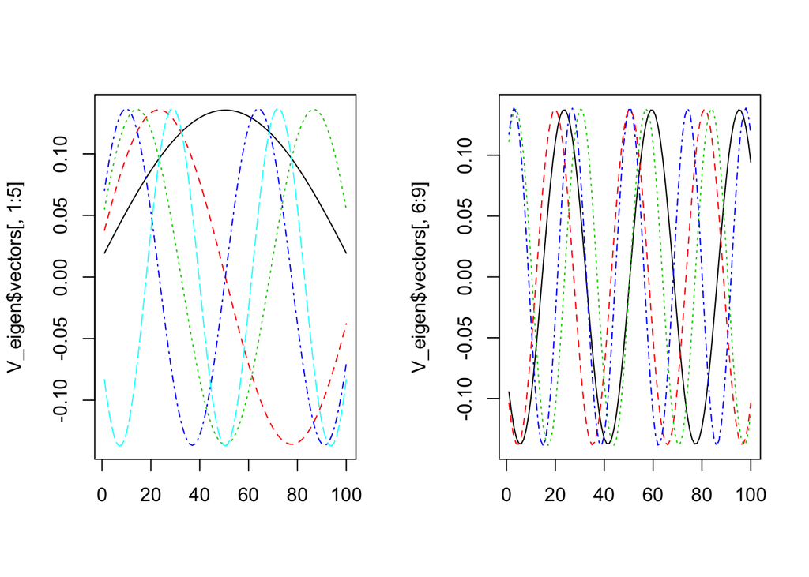

```r
N <- 100; phi <- 0.8; sigma <- 1
V <- matrix(NA,N,N)
for(m in 1:N) for(n in 1:N) V[m,n]<-sigma^2*phi^abs(m-n)/(1-phi^2)
V_eigen <- eigen(V,symmetric=TRUE)
par(mfrow=c(1,2))
# each vector is a 100-length vector, (corresponds to x axis)
matplot(V_eigen$vectors[,1:5],type="l")
matplot(V_eigen$vectors[,6:9],type="l")
```

```r
round(V_eigen$values[1:9],2)
```

```
## [1] 24.59 23.44 21.73 19.70 17.57 15.51 13.61 11.91 10.42
```

We see that the eigenvalues are decreasing. In this model, the components of $Y_{1:N}$ with highest variance correspond to long-period oscillations.

Suppose $\{Y_n,-\infty<n<\infty\}$ has a stationary autocovariance function $\gamma_h$. Write $\Gamma$ for the infinite matrix with entries $\Gamma_{m, n}=\gamma_{m-n}$ for all integers $m$ and $n$

An infinite eigenvector is a sequence $u=\{u_n, -\infty<n<\infty\}$ with corresponding eigenvalue $\lambda$ such that
$$\Gamma u = \lambda u,$$
writing out the matrix multiplication explicitly,
$$\sum_{n=-\infty}^{\infty} \Gamma_{m, n} u_{n}=\lambda u_{m} \quad \text { for all } m$$
We look for a sinusoidal solution $u_n = e^{i\omega n}$.
$$\sum_{n=-\infty}^{\infty} \Gamma_{m, n} u_{n}=\sum_{n=-\infty}^{\infty} \gamma_{m-n} u_{n} = u_m\lambda(\omega)$$
where
$$\lambda(\omega)=\sum_{h=-\infty}^{\infty} \gamma_{h} e^{-i \omega h}$$
is the **spectral density function** and is calculated as the **Fourier transform** of $\gamma_h$ at frequency $\omega$.

### Spectrum of a time series model

**Frequency components** of $Y_{1:N}$ are the components in the directions of its eigenvectors, or Fourier basis. We write
$$\begin{aligned}
&C_{n}=\frac{1}{\sqrt{N}} \sum_{k=1}^{N} Y_{k} \cos \left(\omega_{n} k\right) \text { for } 0 \leq n \leq N / 2\\
&S_{n}=\frac{1}{\sqrt{N}} \sum_{k=1}^{N} Y_{k} \sin \left(\omega_{n} k\right) \text { for } 1 \leq n \leq N / 2
\end{aligned}$$

Similarly, the frequency components of data $y_{1:N}$ are
$$\begin{aligned}
c_{n} &=\frac{1}{\sqrt{N}} \sum_{k=1}^{N} y_{k} \cos \left(\omega_{n} k\right) \text { for } 0 \leq n \leq N / 2 \\
s_{n} &=\frac{1}{\sqrt{N}} \sum_{k=1}^{N} y_{k} \sin \left(\omega_{n} k\right) \text { for } 1 \leq n \leq N / 2
\end{aligned}$$

The frequency components $(C_{0:N/2}, S_{1:N/2})$ are **asymptotically uncorrelated**. Moving to the frequency domain (i.e., transforming the data to its frequency components) has decorrelated the data.

The power of a wave is proportional to the square of its amplitude. The spectral density gives the mean square amplitude of the components at each frequency, and therefore gives the expected power. **The spectral density function can therefore be called the power spectrum**.

### Data analysis under the frequency domain

```r
y <- read.table(file="data/ann_arbor_weather.csv",header=TRUE)
head(y[,1:9],3)
```

```
##   Year Low High Hi_min Lo_max Avg_min Avg_max Mean Precip
## 1 1900  -7   50     36     12      18    34.7 26.3   1.06
## 2 1901  -7   48     37     20      17    31.8 24.4   1.45
## 3 1902  -4   41     27     11      15    30.4 22.7   0.60
```

We have to deal with the NA measurement for 1955. A simple approach is to replace the NA by the mean. What are the strengths and weaknesses of these approaches?

```r
low <- y$Low  # low is the sequence of low temperature data series
low[is.na(low)] <- mean(low, na.rm=TRUE)  # set NA values to mean
```

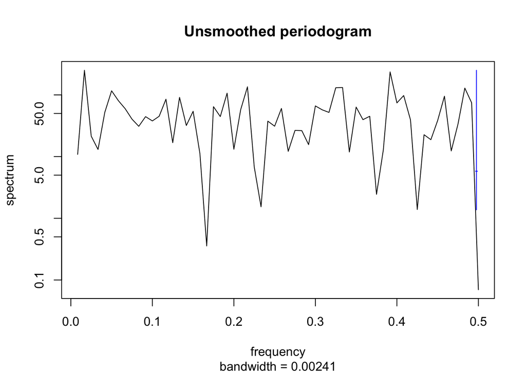

```r
spectrum(low, main="Unsmoothed periodogram")
```

To smooth, we use the default periodogram smoother in R.

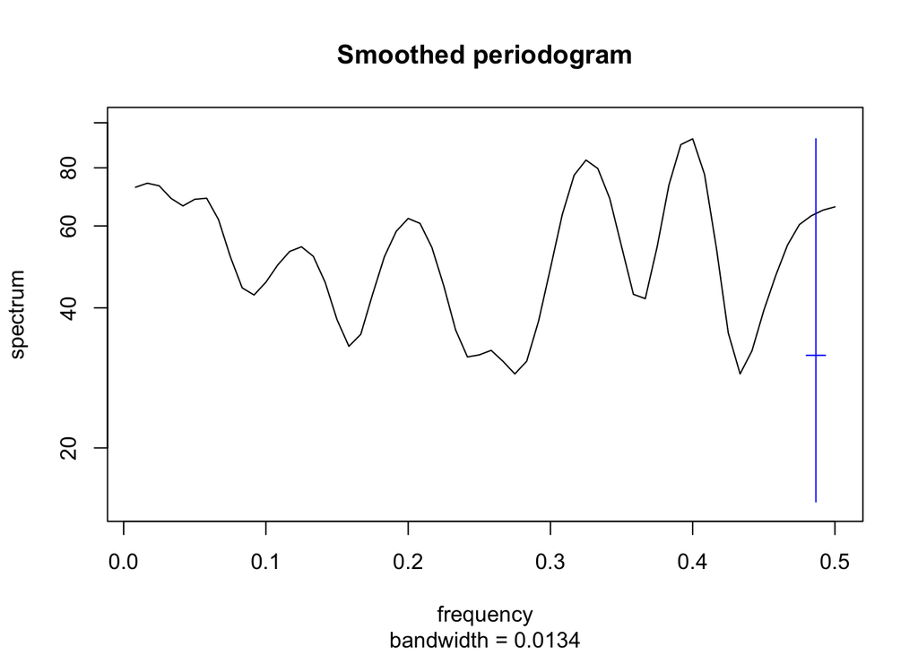

```r
spectrum(low, spans=c(3,5,3), main="Smoothed periodogram",ylim=c(15,100))
```